# BDS516 Homework #9

Quinn Rhodes

4/21/2021

$$\\[.01in]$$

#### Packages

```r
library(rtweet)
library(httpuv)
library(tidytext)
library(tidyverse)
library(dplyr)
library(lubridate)
library(ggplot2)
library(scales)
library(readr)
library(syuzhet)
library(mlbench)
library(caret)
library(vtreat)
library(InformationValue)
```

Methods  
Twitter data from both Kanye West and Barack Obama was collected through a Twitter Developer account. After receiving a twitter API, tweets from both @kanyewest and @BarackObama were extracted from twitter in R Studio using the rtweet package. Other packages used to run models, manage and clean data, create visuals, text mine, run text analyses, and calculate statistics include: httpuv, tidytext, tidyverse, dplyr, lubridate, ggplot, scales, readr, syuzhet, mlbench, caret, vtreat, and InformationValue.  
Of all tweets posted, 3,200 tweets from both @BarackObama and @kanyewest were sampled randomly on April 21st, 2021. Dataframes containing the two sets of tweets were cleaned to only contain the source (which device the tweet was made on), status_id (ID of the tweet), text (text content of the tweet), created_at (time when tweet was created), retweet_count (number of retweets), favorite_count (number of favorites), is_retweet (whether or not the tweet is a retweet), and screen_name (screen name of the individual who tweeted it).  
Prior to modeling, a number of summary statistics were calculated. To analyze differences in source of tweets, the count function was used to examine from which device both Kanye and Obama tweeted from most often. For time of day, the percent of total tweets sampled tweeted at each hour of the day was calculated for both Kanye and Obama and graphed as a line graph. Time tweeted was standardized using Eastern Standard Time (EST). Furthermore, the percentage of total tweets sampled starting with a quotation mark was calculated. Tendencies to include pictures or links in tweets was captured by calculating the total percentage of tweets containing either a picture, a link, or both among the tweets sampled. Furthermore, retweets and favorites were analyzed by calculating the percentage of tweets that are retweets out of the total sample, the average number of retweets on each of their tweets among the tweets sampled, and the average number of favorites on each of their tweets among the tweets sampled. Lastly, average sentiment for tweets were calculated for both Kanye and Obama. This was performed by removing all non-alphabetic characters using the str_replace_all command. Sentiment scores were calculated using the NRC Sentiment Dictionary. By running the command get_nrc_sentiment, sentiment scores were calculated for tweet texts. The average for both Kanye and Obama was then calculated for each of the following sentiments and valence: anticipation, fear, disgust, joy, sadness, surprise, trust, negative valence, and positive valence. Notably, percentages were used for comparisons because Kanye had fewer than 3,200 tweets while Obama had enough tweets to reach 3,200 sample tweets. Therefore, this was done to account for the difference in total number of tweets in the dataset for each person.  
Multiple logistic regression was used to develop the predictive algorithm, using the glm function in R. The following predictors were included: whether the tweet uses a quotation mark, whether the tweet features a picture or link, and sentiment scores for the sentiments anticipation, fear, joy, trust, and positive valence. These factors were chosen due to a notable difference in behaviors observed between Kanye and Obama based on the summary statistics. The outcome variable was captured as being tweeted by Obama or not tweeted by Obama (i.e. tweeted by Kanye). The algorithms predictive power was then tested on a new set of tweets made by both Kanye and Obama. A train-test split was created with 70% of tweets from both Kanye and Obama included in the train set and 30% from each included in the test set. Model diagnostics were calculated, including the optimal prediction probability cutoff, the misclassification error, the sensitivity level, and the specificity level. An AUC-ROC curve was created to demonstrate the ability to distinguish between the positive (i.e. Obama’s tweets) and negative class (i.e. Kanye’s tweet). Lastly, the model was used on a set of tweets from an unrelated user. A random sample of 3,200 of Drake’s tweets (@Drake) run through the model. Examples of tweets by Drake that were classified as Obama and Kanye were then analyzed by examining how the characteristics of the tweets related to each component included in the model.

#### Set up

```r
## Setting up authentication to get to twitter
twitter_token <- create_token(
  app = "Classwork for BDS 516",
  consumer_key = "W30dWiQN5oTkPBRGE9CYEyidm",
  consumer_secret = "23xMeQn3rvircKaGWcbLlO7lhrXKIanpH3nsZMrzyZUD3Pe3JF",
  access_token = "1148924254966226945-jBqguRa05UmaF4HsujuERFo6KeBwtu",
  access_secret = "nAi2Y3fD1k6odmn1OVmuM6R32Q7UBVxiMpkWTEypckEWz")

## Getting tweets from Obama and Kanye
obama_raw <- get_timeline("@BarackObama", n = 3200)
kanye_raw <- get_timeline("@kanyewest", n = 3200)

## Cleaning the data sets

# Obama
obama_clean <- obama_raw %>% select("source", "status_id", "text","created_at",
                                "retweet_count", "favorite_count", "is_retweet", "screen_name")
# Kanye
kanye_clean <- kanye_raw %>% select("source", "status_id", "text","created_at",
                                "retweet_count", "favorite_count", "is_retweet", "screen_name")

## Saving files as csvs for ease of use
obama_clean <- as.data.frame(obama_clean)
write.csv(x=obama_clean, file="obama_tweets.csv")
kanye_clean <- as.data.frame(kanye_clean)
write.csv(x=kanye_clean, file="kanye_tweets.csv")
```

```r
## Loading in csv files
setwd("~/Documents/*MBDS/BDS 516/Data")
obama <- read_csv("obama_tweets.csv")
kanye <- read_csv("kanye_tweets.csv")
```

$$\\[.01in]$$

### Feature Extraction

#### *(1.) Source*

```r
obama %>% count(source) %>% arrange(-n)
kanye %>% count(source) %>% arrange(-n)
```

```
# A tibble: 5 x 2
  source                   n
  <chr>                <int>
1 Twitter Web Client    2446
2 Twitter for iPhone     473
3 Twitter Web App        199
4 Twitter Media Studio    76
5 Thunderclap              5
# A tibble: 2 x 2
  source                 n
  <chr>              <int>
1 Twitter for iPhone  1830
2 Twitter Web App       38
```

Obama most frequently tweets from a desktop/laptop while Kanye most frequently tweets from an iPhone.

#### *(2.) Time of Day*

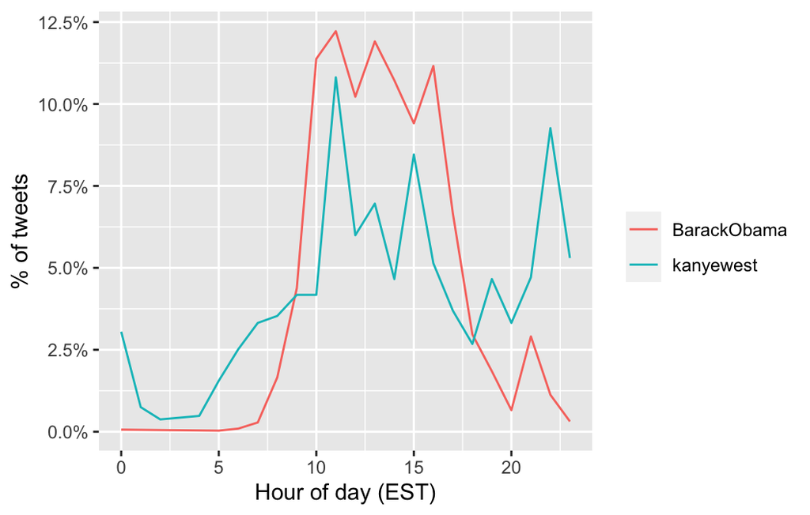

```r
merged_df <- rbind(obama, kanye)

merged_df %>% group_by(screen_name) %>%
  count(hour = hour(with_tz(created_at, "EST"))) %>%
  mutate(percent = n/sum(n)) %>%
  ggplot(aes(x = hour, y = percent, color = screen_name)) +
  labs(x = "Hour of day (EST)", y = "% of tweets", color = "") +
  scale_y_continuous(labels = percent_format()) +
  geom_line()
```

The vast majority of Obama’s tweets are posted between 10am and 4pm, while, Kanye’s tweets have much more variability.

#### *(3.) Quotes*

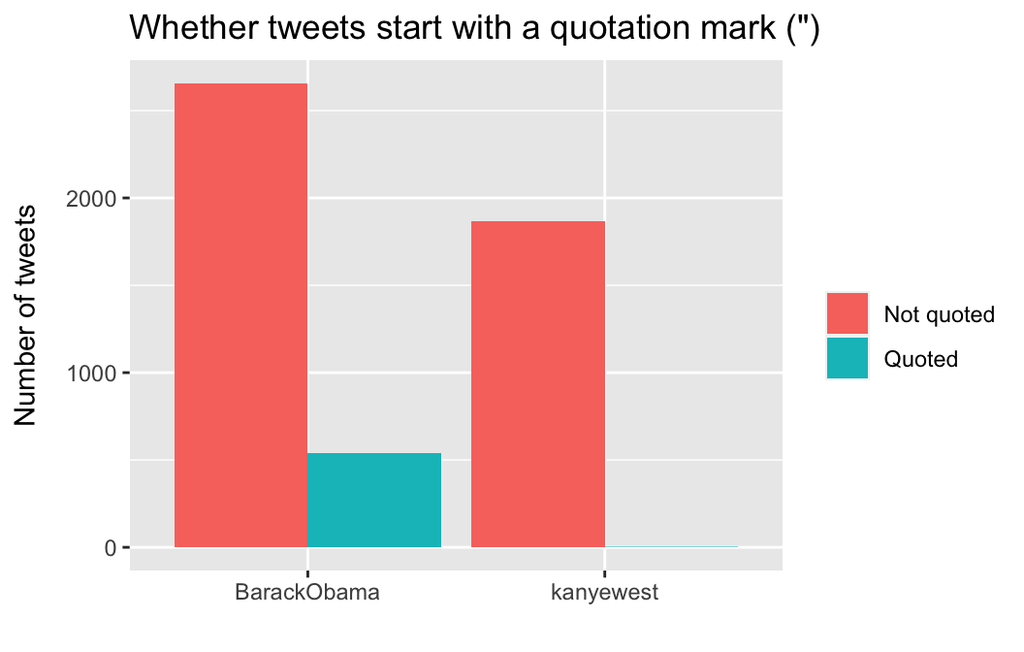

```r
## Plot of tweets with quotes vs. no quotes
merged_df %>% group_by(screen_name) %>%
  count(quoted = ifelse(str_detect(text, '^"'), "Quoted", "Not quoted")) %>%
  ggplot(aes(x = screen_name, y = n, fill = quoted)) +
  geom_bar(stat = "identity", position = "dodge") +
  labs(x = "", y = "Number of tweets", fill = "") +
  theme(axis.title.y = element_text(margin = margin(t = 0, r = 10, b = 0, l = 0))) +
  ggtitle('Whether tweets start with a quotation mark (")')
```

```r
# Table of tweets with quotes vs. no quotes
merged_df %>% group_by(screen_name) %>%
  count(quoted = ifelse(str_detect(text, '^"'), "Quoted", "Not quoted")) %>%
  mutate(percent_quote = n/sum(n)*100)
```

```
# A tibble: 4 x 4
# Groups:   screen_name [2]
  screen_name quoted         n percent_quote
  <chr>       <chr>      <int>         <dbl>
1 BarackObama Not quoted  2657        83.1
2 BarackObama Quoted       542        16.9
3 kanyewest   Not quoted  1865        99.8
4 kanyewest   Quoted         3         0.161
```

Both Obama and Kanye do not quote very much in their tweets; however, ~17% of Obama’s tweets use quotes, while Kanye quotes less than 1% of the time.

#### *(4.) Pictures*

```r
merged_df %>%
  group_by(screen_name) %>%
  filter(!str_detect(text, '^"')) %>%
  count(picture = ifelse(str_detect(text, "t.co"),
                         "Picture/link", "No picture/link")) %>%
  mutate(percent_picture = n/sum(n)*100)
```

```
# A tibble: 4 x 4
# Groups:   screen_name [2]
  screen_name picture             n percent_picture
  <chr>       <chr>           <int>           <dbl>
1 BarackObama No picture/link   210            7.90
2 BarackObama Picture/link     2447           92.1
3 kanyewest   No picture/link   842           45.1
4 kanyewest   Picture/link     1023           54.9
```

The vast majority of Obama’s tweets include a picture or link (92%), while only 55% of Kanye’s tweets contain a picture or link.

#### *(5.) Re-tweets*

```r
merged_df %>% group_by(screen_name) %>%
  count(is_retweet) %>%
  mutate(perc_retweet = n/sum(n)*100)
```

```
# A tibble: 4 x 4
# Groups:   screen_name [2]
  screen_name is_retweet     n perc_retweet
  <chr>       <lgl>      <int>        <dbl>
1 BarackObama FALSE       2847         89.0
2 BarackObama TRUE         352         11.0
3 kanyewest   FALSE       1670         89.4
4 kanyewest   TRUE         198         10.6
```

Obama and Kanye have nearly the same percentage of tweets that are re-tweets.

#### *(6.) Re-tweet Counts & Favorite Counts*

```r
merged_df %>% group_by(screen_name) %>%
  summarize(avg_retweet = mean(retweet_count),
            avg_fav = mean(favorite_count))
```

```
# A tibble: 2 x 3
  screen_name avg_retweet avg_fav
* <chr>             <dbl>   <dbl>
1 BarackObama      11367.  58068.
2 kanyewest         9314.  48920.
```

On average, a tweet posted by Obama is re-tweeted ~11,4000 times and is favorited by 60,000 people. For Kanye, the average tweet is re-tweeted ~9,000 times and favorited by ~50,000 people. However, these differences do not seem to be a meaningful metric of comparison given the fact that Obama has 130 million twitter followers, while Kanye has only 30 million.

#### *(7.) Sentiment*

```r
merged_sentiment <- merged_df %>%
  mutate(text2 = str_replace_all(text, "[^[:alpha:]]", " "), # removes all non-alphabetic characters
         get_nrc_sentiment(text2)) # getting nrc scores for tweet texts
```

```r
merged_sentiment %>%
  group_by(screen_name) %>%
  summarize(anger = mean(anger),
            anticipation = mean(anticipation),
            fear = mean(fear),
            disgust = mean(disgust),
            joy = mean(joy),
            sadness = mean(sadness),
            surprise = mean(surprise),
            trust = mean(trust),
            negative = mean(negative),
            positive = mean(positive))
```

```
  screen_name anger anticipation  fear disgust   joy sadness surprise trust
1 BarackObama 0.315        0.738 0.452   0.100 0.565   0.233    0.284 1.247
2   kanyewest 0.148        0.305 0.213   0.071 0.376   0.153    0.120 0.414
  negative positive
1    0.516    1.778
2    0.268    0.742
```

Obama’s tweets (on average) seemingly score higher across all sentiment scores. This is particularly true for “anticipation”, “trust”, and “positive” sentiments

$$\\[.01in]$$

# Part A

*Develop an algorithm that allows to predict who of the politicians tweeted using just the information in the text of the tweet and the time of the tweets. You are not allowed to use the information about the user. You can use sentiments, individual words, punctuation and anything else as a source of features.*

##### Based off the feature extraction above, we believe that the features which most contribute to the prediction of whether a tweet was authored by Obama vs. Kanye are: **source, quotes, pictures, and sentiment scores.** We now will develop a classification algorithm using **logistic regression model** to predict the probability of a tweet being authored by Obama. As such, the *outcome variable* will be a tweet by Obama (yes or no) and the *predictor variables* will be some combination of the features mentioned above. To that end, we will run several logistic regression models, but only include the model with the greatest predictive power.

```r
## Setting up data frame for logistic regression
obama_kanye <- merged_sentiment

# Changing names of sources (before filtering)
obama_kanye$source[obama_kanye$source=="Twitter Web Client"] <- "web"
obama_kanye$source[obama_kanye$source=="Twitter for iPhone"] <- "iphone"

obama_kanye2 <- obama_kanye %>%
  select(screen_name, source, created_at, text, status_id,
         anger, anticipation, fear, disgust, joy, sadness, surprise, trust, negative, positive) %>%
  # filtering twitter sources for only web/iPhone
  filter(source %in% c("web", "iphone")) %>%
  # creating variables for time of day, whether the tweet uses a quote, and whether
  # there is a picture or link in the tweet
  mutate(hour = hour(with_tz(created_at, "EST")),
         quoted = ifelse(str_detect(text, '^"'), "quote", "NO_quote"),
         picture = ifelse(str_detect(text, "t.co"), "picture_link", "NO_picture_link"),
         is_obama = case_when(screen_name == "BarackObama" ~ 1,
                              screen_name == "kanyewest" ~ 0))

# Selecting variables for regression
obama_kanye3 <- obama_kanye2 %>%
  select(is_obama, screen_name, source, hour, quoted, picture,
         anger, anticipation, fear, disgust, joy, sadness, surprise, trust, negative, positive)
```

#### **Logistic Regression Model**

```r
model <- glm(is_obama ~  factor(quoted) + factor(picture) +
                anticipation + fear + joy + trust + positive,
             family = "binomial",
             data = obama_kanye3)

summary(model)
```

```
Call:
glm(formula = is_obama ~ factor(quoted) + factor(picture) + anticipation +
    fear + joy + trust + positive, family = "binomial", data = obama_kanye3)

Deviance Residuals:
    Min       1Q   Median       3Q      Max
-4.2721  -0.5638   0.1219   0.6557   2.7422

Coefficients:
                            Estimate Std. Error z value Pr(>|z|)
(Intercept)                 -3.73624    0.14608 -25.577  < 2e-16 ***
factor(quoted)quote          6.68145    0.72076   9.270  < 2e-16 ***
factor(picture)picture_link  3.40283    0.13426  25.345  < 2e-16 ***
anticipation                 0.55618    0.08228   6.759 1.38e-11 ***
fear                         0.57846    0.07464   7.750 9.16e-15 ***
joy                         -1.15137    0.09472 -12.156  < 2e-16 ***
trust                        0.73190    0.07298  10.029  < 2e-16 ***
positive                     0.82058    0.06216  13.201  < 2e-16 ***
---
Signif. codes:  0 '***' 0.001 '**' 0.01 '*' 0.05 '.' 0.1 ' ' 1

(Dispersion parameter for binomial family taken to be 1)

    Null deviance: 6331.6  on 4748  degrees of freedom
Residual deviance: 3750.2  on 4741  degrees of freedom
AIC: 3766.2

Number of Fisher Scoring iterations: 8
```

```r
exp(model$coefficients)
```

```
                (Intercept)         factor(quoted)quote
                 0.02384356                797.47143283
factor(picture)picture_link                anticipation
                30.04893338                  1.74400434
                       fear                         joy
                 1.78329704                  0.31620393
                      trust                    positive
                 2.07902310                  2.27180811
```

#### *Interpretation of Model*

- “**quoted**”
  - All else equal, tweets with quotes have a ~80,000% greater odds of being Obama’s tweets.
  - *Calculation:* odds = (797.47143283 - 1)*100 = 79647.14
- “**picture_link**”
  - All else equal, tweets with pictures or links have a ~3,000% greater odds of being Obama’s tweets.
  - *Calculation:* odds = (30.04893338 - 1)*100 = 2904.893
- “**anticipation**”
  - All else equal, a one-unit increase in the sentiment score for anticipation increases the odds of the tweet being authored by Obama by 74%.
  - *Calculation:* odds = (1.74400434 - 1)*100 = 74.40043
- “**fear**”
  - All else equal, a one-unit increase in the sentiment score for fear increases the odds of the tweet being authored by Obama by 78%.
  - *Calculation:* odds = 1.78329704 - 1)*100 = 78.3297
- “**joy**”
  - All else equal, a one-unit increase in the sentiment score for joy decreases the odds of the tweet being authored by Obama by 68%.
  - *Calculation:* odds = (0.31620393 - 1)*100 = -68.37961
- “**trust**”
  - All else equal, a one-unit increase in the sentiment score for trust increases the odds of the tweet being authored by Obama by 108%.
  - *Calculation:* odds = (2.07902310 - 1)*100 = 107.9023
- “**positive**”
  - All else equal, a one-unit increase in the sentiment score for positive increases the odds of the tweet being authored by Obama by 127%.
  - *Calculation:* odds = (2.27180811 - 1)*100 = 127.1808

$$\\[.01in]$$

# Part B

*Apply the algorithm to new tweets from both users to estimate how well the predictions work.*

##### Given that our logistic regression model was developed using *all* of the tweets ever posted by Kanye West (n = 1,868), rather than applying the algorithm to a new tweets, we will evaluate the algorithm using a **train-test split**.

### **Train-Test Split Evaluation**

```r
# Checking for class bias
table(obama_kanye3$is_obama)
```

```
##
##    0    1
## 1830 2919
```

```r
## Creating train and test data

# Ensuring Train Data draws equal proportions of Obama (1) and Kanye (0))
set.seed(04917)
input_ones <- obama_kanye3[which(obama_kanye3$is_obama == 1), ]  # all 1's
input_zeros <- obama_kanye3[which(obama_kanye3$is_obama == 0), ]  # all 0's

# 1's for training
input_ones_training_rows <- sample(1:nrow(input_ones), 0.7*nrow(input_ones))
training_ones <- input_ones[input_ones_training_rows, ]

# 0's for training. Pick as many 0's as 1's
input_zeros_training_rows <- sample(1:nrow(input_zeros), 0.7*nrow(input_zeros))
training_zeros <- input_zeros[input_zeros_training_rows, ]

#Row bind the 1's and 0's
train.data <- rbind(training_ones, training_zeros)

# Creating Test Data
test_ones <- input_ones[-input_ones_training_rows, ]
test_zeros <- input_zeros[-input_zeros_training_rows, ]

# Row bind the 1's and 0's
test.data <- rbind(test_ones, test_zeros)

## Building Logistical Model and Predicting on Test Data
model_train <- glm(is_obama ~  factor(quoted) + factor(picture) +
                anticipation + fear + joy + trust + positive,
                data=train.data,
                family=binomial(link="logit"))

predicted <- predict(model_train, test.data, type="response")
```

### **Model Diagnostics**

```r
# Optimal prediction probability cutoff
optCutOff <- optimalCutoff(test.data$is_obama, predicted)
optCutOff #  = 0.52
```

#### *Misclassification Error*

```r
misClassError(test.data$is_obama, predicted, threshold = optCutOff)
```

```
[1] 0.1537
```

#### *AUC-ROC Curve*

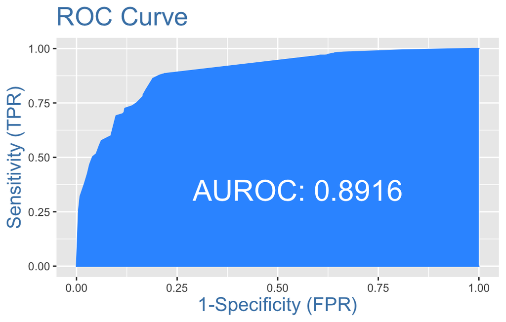

```r
plotROC(test.data$is_obama, predicted)
```

Our model has an AUC of .9, meaning there is a ~90% chance that the model will be able distinguish between positive class (i.e. Obama’s tweets) and negative class (i.e. Kanye’s tweets)

#### *Sensitivity and Specificity*

```r
sensitivity(test.data$is_obama, predicted, threshold = optCutOff)
specificity(test.data$is_obama, predicted, threshold = optCutOff)
```

```
[1] 0.8812785
[1] 0.7905282
```

##### **All in all, our model has fairly strong predictive ability**

$$\\[.01in]$$

# Part C

*Try the prediction algorithm with a different set of tweets from unrelated users. Discuss how the algorithm works / breaks in this case.*

##### In the following section, we will apply our prediction algorithm (i.e. the trained logistic model created above) to a set of tweets posted by the rapper, **Drake**.

#### *Preparing a data set of Drake Tweets*

```r
## Creating a data set for Drake Tweets

# Extracting data from Twitter
drake_raw <- get_timeline("@Drake", n = 3200)


# Cleaning the data sets
drake_clean <- drake_raw %>% select("source", "status_id", "text","created_at",
                                "retweet_count", "favorite_count", "is_retweet",
                                "screen_name")

drake <- as.data.frame(drake_clean)
```

```r
## Getting sentiment scores
drake_sentiment <- drake %>%
  mutate(text2 = str_replace_all(text, "[^[:alpha:]]", " "), # removes all non-alphabetic characters
         get_nrc_sentiment(text2)) # getting nrc scores for tweet texts
```

```r
## Preparing data set for testing
drake_test <- drake_sentiment

drake_test2 <- drake_test %>%
  # creating variables for whether the tweet uses a quote & whether there is a picture/link
  mutate(quoted = ifelse(str_detect(text, '^"'), "quote", "NO_quote"),
         picture = ifelse(str_detect(text, "t.co"), "picture_link", "NO_picture_link")) %>%
  select(screen_name, text2, quoted, picture,
         anticipation, fear, joy, trust, positive)

## Sanity check
head(drake_test2)
```

```
# A tibble: 6 x 9
  screen_name text2       quoted picture anticipation  fear   joy trust positive
  <chr>       <chr>       <chr>  <chr>          <dbl> <dbl> <dbl> <dbl>    <dbl>
1 Drake       Tune in  h… NO_qu… pictur…            0     0     0     0        0
2 Drake       Fry Yiy ht… NO_qu… pictur…            0     0     0     0        0
3 Drake       What s Nex… NO_qu… pictur…            0     0     0     1        0
4 Drake       SCARY HOUR… NO_qu… pictur…            0     0     0     0        0
5 Drake       Going live… NO_qu… pictur…            1     0     0     0        2
6 Drake       SCARY HOUR… NO_qu… pictur…            0     0     0     0        0
```

#### *Applying Prediction Algorithm on Drake Tweets*

```r
## Predicting the train logistical regression model on the drake data
predicted_drake <- predict(model_train, drake_test2, type="response")
predicted.classes <- ifelse(predicted_drake > 0.5, "Obama", "Kanye")
table(predicted.classes)
```

```
predicted.classes
Kanye Obama
 1583   164
```

When the original prediction algorithm was used on a data set of tweets posted by Drake, the algorithm classified 91% of the tweets as being Kanye West’s tweets and 9% being Obama’s. Given this result, it would be interesting to look at examples of Drake’s tweets that were classified as Kanye’s vs. Obama’s.

```r
drake_test3 <- drake_test2
drake_test3$predictions <- predicted.classes
drake_test3 <- drake_test3 %>%
  mutate(n = row_number())
```

##### *Example:* Predicted Classification of Tweet = **Obama**

```r
drake_test3 %>% filter(n == 36) %>%
  pull(text2)
```

```
[1] "URL x CAFFEINE Excited to announce this major step forward   I managed to get  urltv and  caffeine linked up with the objective of making battle rap easier to access in you home or on your mobile device and it s FREE to watch battles once you sign up  Greatness Simplified  https   t co  XqosqiN…
```

##### *Example:* Predicted Classification of Tweet = **Kanye**

```r
drake_test3 %>% filter(n == 121) %>%
  pull(text2)
```

```
[1] "To the city I love and the people in it   Thank you for everything  VIEWS https   t co HEXHNwrWwd"
```

The first example shows a Drake tweet that was classified as an *Obama* tweet. This tweet did not begin with a quote/link but included a picture., and its sentiment scores were as follows: anticipation = 4; fear = 1; joy = 2; trust = 3; positive = 5. Given that our algorithm found that pictures and sentiments of anticipation, fear, trust, and positive *all* increase the odds of a tweet belonging to Obama (versus Kanye), it is unsurprising that example #1 was coded as an Obama tweet. The second example shows a Drake tweet that was classified as a *Kanye* tweet. This tweet also did not begin with a quote, included a picture, and its sentiment scores were as follows: anticipation = 0; fear = 0; joy = 1; trust = 0; positive = 0. While our algorithm found that a one unit increase in the sentiment score for joy *decreases* the odds of the tweet being authored by Obama by 68%, it also found that tweets with pictures/links have a ~3,000% greater odds of being Obama’s tweets. As such, this classification seems to be rather odd. All in all, it is clear that our algorithm is only as good as the data it is provided.

Results  
Summary Statistics  
Primary Tweet Source  
When analyzing the source of Kanye and Obama’s tweets, we see that Kanye primarily tweets from an iPhone (n=1830 or ~98%) while Obama primarily tweets from a desktop/laptop computer (n=2446 or ~76.5%).  
Time of Day  
The majority of Obama’s tweets were made between 10am and 4pm with very few made before 7 am or after 9 pm. This is potentially due to staffers making many of his tweets on his behalf, especially for tweets made while he was in office. On the contrary, Kanye’s time of tweets is much more variable, with many tweets being made in the late morning/early afternoon (~11 am to 3 pm) but a considerable number being made late at night (~9 pm to 1 am). This may indicate fewer individuals making tweets on Kanye’s behalf/a more personal use of twitter since these tweets are occurring outside the typical workday.  
Percentage of Tweets Starting with Quotation Marks  
While neither Kanye nor Obama begin tweets with quotation marks particularly often, Obama does appear to use them significantly more since Kanye uses them so infrequently. While 17% of Obama’s tweets use quotes at the beginning, fewer than 1% of Kanye’s tweets use quotation marks.  
Percentage of Tweets Containing Pictures or Links  
Whether or not a tweet contains pictures may also be useful information for predicting whether a tweet was made by Obama or Kanye. Out of this sample, 92% of Obama’s tweets contain a picture or link whereas only 55% of Kanye’s tweets do.  
Percentage of Tweets that are Re-tweets  
Obama and Kanye have nearly the same percentage of tweets that are retweets. 11% of Obama’s tweets are retweets and 10.6% of Kanye’s tweets are retweets.  
Retweet/Favorite Counts on Original Tweets  
Overall, Obama gets 11,400 retweets on average and 58,068 favorites. Meanwhile, Kanye gets 9,314 retweets on average and 48,920 favorites. However, it is important to note that Obama has 130 million followers and Kanye only has 30 million followers. This may indicate a higher engagement rate with Kanye’s tweets compared to Obama’s. Considering we are looking at average retweets/favorites regardless of follower count, the similarities in retweet and favorite counts for Kanye and Obama may indicate that these characteristics may not be particularly predictive.  
Sentiment  
On average, it seems that Obama expressed more emotion through his tweets than Kanye. Obama’s tweets had a higher sentiment score across all sentiments included in this analysis (i.e. anticipation, fear, disgust, joy, sadness, surprise, trust, negative valence, positive valence) compared to Kanye. Obama’s tweets scored particularly higher for “anticipation”, “trust”, and “positive valence”.  
Predictive Algorithm  
All predictors in our logistic regression model were significant at the p<.001 level when holding the other predictors constant. Whether or not the tweet included a quotation mark had an odds ratio of 797. This means that tweets containing a quotation mark have a 797x greater odds of being Obama’s tweets than Kanye’s tweets when all other predictors in the model are held constant. Furthermore, tweets with a picture or link included have a 30x greater odds of being Obama’s tweet than being Kanye’s tweet when all other predictors are held constant. Sentiments do not demonstrate such a strong relationship with the author of the tweet, but do demonstrate a meaningful relationship. The odds ratios for anticipation, fear, trust, joy, and positive valence are 1.74, 1.78, 2.08, 0.316, and 2.27, respectively. This means that tweets expressing more anticipation, fear, trust, and positive valence have a higher odds of being tweeted by Obama. Nonetheless, tweets with higher joy scores have a lower odds of being authored by Obama. Unfortunately, Kanye’s total number of tweets did not sum up to 3,200. Therefore, there were no new tweets to run the algorithm on. Therefore, the model was evaluated on a 70-30 train-test split. Using the test data, the optimal prediction probability cutoff was found to be 0.52. Furthermore, the misclassification error was 0.15, indicating that the percentage of incorrectly classified instances is 15% and the AUROC was 0.8916, indicating that there is a 90% chance that the model will be able to distinguish between the positive class (i.e. Obama’s tweets) and the negative class (i.e. Kanye’s tweets). Furthermore, the sensitivity and specificity were 0.88 and 0.79, meaning that the model correctly identified Obama’s tweets as being tweeted by Obama 88% of the time and the model correctly identified tweets by Kanye as being tweeted by Kanye 79% of the time. Overall, these diagnostics indicate that our model has strong predictive power in distinguishing between tweets by Kanye and tweets by Obama.  
Running the Algorithm on @Drake’s Tweets  
When the original prediction algorithm was used on a data set composed of tweets posted by just Drake, the algorithm classified 91% of those tweets as being Kanye West's tweets and 9% being Obama's. When pulling a tweet from Drake that was classified as an Obama tweet, we found that the tweet did not begin with a quote or link but included a picture. It had an anticipation score of 4; fear score of 1; joy score of 2; trust score of 3; and positive score of 5. Given that our algorithm found that pictures and sentiments of anticipation, fear, trust, and positive *all* increase the odds of a tweet belonging to Obama instead of Kanye, it is unsurprising that a tweet by Drake consisting of an image and with such sentiment scores was coded as an Obama tweet. We then pulled a Drake tweet that was classified as a Kanye tweet. This tweet also did not begin with a quote, and included a picture. However the sentiment scores were different. It had an anticipation score of 0; fear score of 0; joy score of 1; trust score of 0; and positive score of 0. While our algorithm found that a one unit increase in the sentiment score for joy *decreases* the odds of the tweet being authored by Obama by 68%, it also found that tweets with pictures and links have a 30 times odd of being an Obama tweet. As such, this classification seems to be rather perplexing given the differing magnitude of these variables.